# STAT 240 Discussion 9

Group 311C: William Fan, Jason Fu, Fei Qin, Nihar Simhadri, **Kai Tsuyoshi**

## Problems

The questions in this discussion assignment use the chimpanzee data set. In answering these questions, you may assume the following in models for the data:

1. all trials are independent
2. trials made with a partner have the same chance of being pro-social, even if the identities of the actors or partners differ.

### Problem 1

#### A

Using the chimpanzee data, combine all of the trials made without a partner. Count the number of pro-social and selfish choices made.

```r
chimpanzee = read_csv("../../data/chimpanzee.csv")

no_part = chimpanzee %>%
  filter(partner == "none") %>%
  summarize(prosocial = sum(prosocial),selfish = sum(selfish), )

no_part
```

```
## # A tibble: 1 × 2
##   prosocial selfish
##       <dbl>   <dbl>
## 1        83      97
```

#### B

Write a model for the number of pro-social choices.

-$n = 180$ => number of trials -$p$ is the probability that the chimpanzees make the pro-social choice -$x = 83$ => number of times the pro-social choice was made in the above dataset for chimpanzees without partners and thus -$\hat{p} = \frac{x}{n} = \frac{83}{180} = 0.461$

#### C

Use the Agresti-Coull method to construct a 95% confidence interval for the probability that a chimpanzee makes the pro-social choice in experimental conditions when there is no partner present.

$$\tilde{p} \pm 1.96 \sqrt{ \frac{\tilde{p}(1-\tilde{p})}{n+4} }$$

```r
binom_se =  function(n, p)
{
  return ( sqrt( p*(1-p)/n) )
}

binom_ci = function(est, se, conf=0.95)
{
  z = qnorm(1 - (1 - conf)/2)
  me = z * se
  ci = est + c(-1,1)*me
  return(ci)
}


x = 83
n = 180

p_tilde = (x+2)/(n+4)
p_tilde
```

```
## [1] 0.4619565
```

```r
se_agresti = binom_se(n+4, p_tilde)
se_agresti
```

```
## [1] 0.03675364
```

```r
ci_agresti = binom_ci(p_tilde, se_agresti)
round(ci_agresti, 3)
```

```
## [1] 0.390 0.534
```

#### D

Interpret this confidence interval in the context of the experimental setting.

### Problem 2

Using the same data as in the previous problem, do the following.

#### A

State hypotheses for a two-sided hypothesis test that the probability that a chimpanzee makes the pro-social choice over the long run is equal to 0.5 versus the alternative that this probability is not 0.5.

- $H_0: p = 0.5$
- $H_a: p \neq 0.5$

#### B

Pick a test statistic, state the sampling distribution of this statistic if the null hypothesis is true, and compute a p-value for the test.

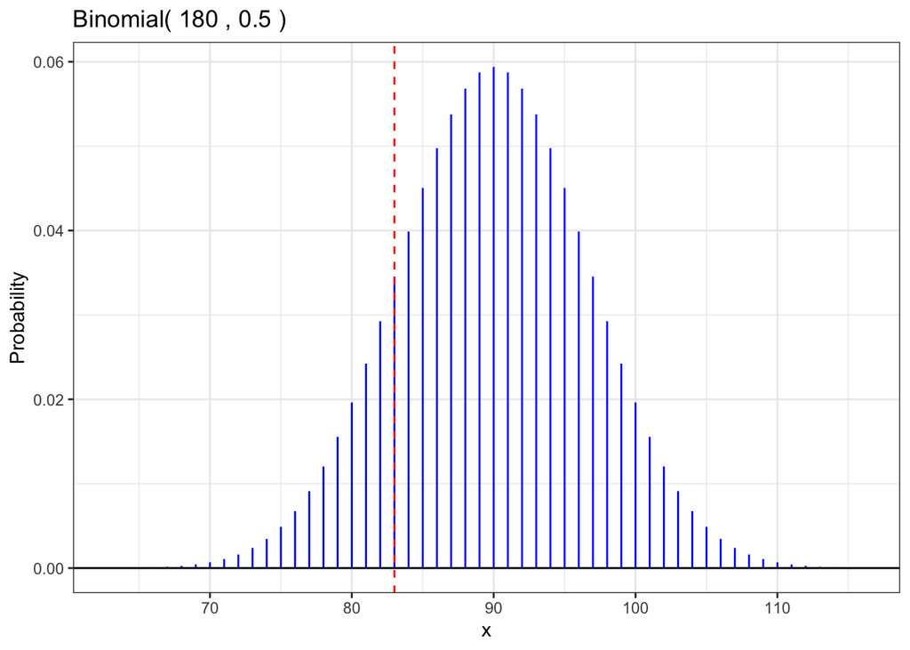

```r
gbinom(180, 0.5, scale=TRUE) +
  geom_vline(xintercept = 83, color="red",
             linetype = "dashed") +

  theme_bw()
```

```r
 p_val = sum(dbinom(c(0:83, 97:180), 180, 0.5))
 p_val
```

```
## [1] 0.3325791
```

#### C

Interpret these results in the context of the experiment following the examples from lecture notes.

### 3

Use functions from the file `ggprob.R` to visualize the calculation of the p-value by graphing an appropriate probability distribution and using differential coloring to indicate what in the plot corresponds to the p-value. Include a title and meaningful axis labels.

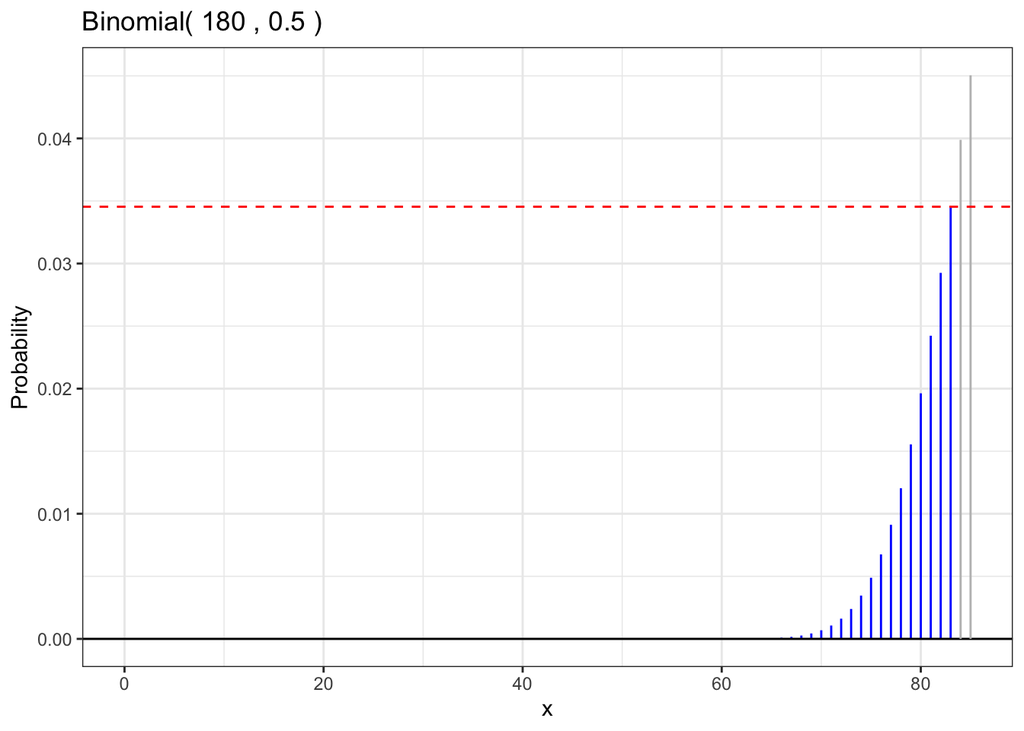

```r
# Left-hand
gbinom(180, 0.5, a = 0, b = 83) +
  geom_binom_density(180, 0.5, a =84, b = 85, color = "gray") +
  geom_hline(yintercept = dbinom(83, 180, 0.5), color = "red", linetype = "dashed") +
  theme_bw()
```

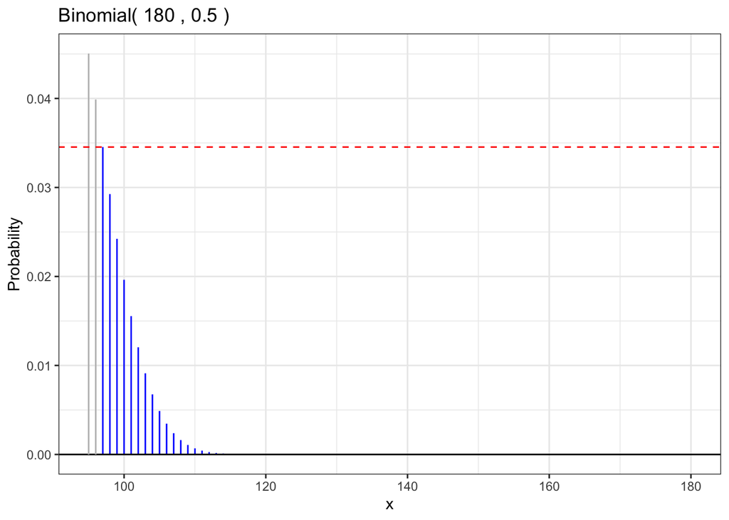

```r
# Right-hand
gbinom(180, 0.5, a = 97, b = 180) +
  geom_binom_density(180, 0.5, a = 95, b = 96, color = "gray") +
  geom_hline(yintercept = dbinom(83, 180, 0.5), color = "red", linetype = "dashed") +
  theme_bw()
```